# Comparando mecanismos para jukebox sociais - Lab 4.3 - FPCC2

# Testes de Hipóteses

Agora vamos utilizar o TH (para H0 e H1) para estimar a diferença entre o up/downvoting e os demais mecanismos (baseline, skip, like/dislike), seguindo o mesmo raciocício dos IC.

Vamos encontrar o valor do theta_chapeu, que representa a diferença das médias das sastifações entre os mecanismos.

Com base nos valores do theta_chapeu e da distribuição das diferenças nas reamostragens poderemos rejeitar ou não H0.

Nesse caso, o H0 (hipótese nula) é se a diferença das médias da sastifação entre os mecanismos não é o valor do theta_chapeu e a H1 é se a diferença das médias da satisfação entre os mecanismos é o valor de theta_chapeu.

```
## [1] 0.3478261 1.8695652 2.2608696 0.7391304
```

```
##       Diferença.dos.mecanismos theta_chapeu
## 1     up/downvoting e combined    0.3478261
## 2         up/downvoting e skip    1.8695652
## 3     up/downvoting e baseline    2.2608696
## 4 up/downvoting e like/dislike    0.7391304
```

# Calculando a Reamostragem

Calculando as diferenças das médias entre os mecanismos para uma repetição de 4000 mil reamostras com base na amostra original.

Análise dos testes de hipóteses

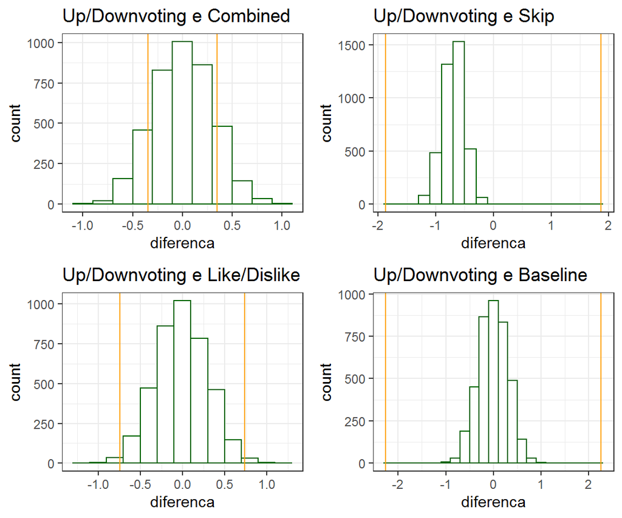

Visualizando o histograma dos mecanismos, é possível constantar que a diferença entre up/downvoting e combined, o valor do theta_chapeu, está compreendido entre a distribuição das diferenças da população, ou seja, não podemos rejeitar o H0. Não podemos afirmar que existe uma diferença significativa entre esses mecanismos.

Já a diferença entre o up/downvoting e baseline é possível verificar que essa diferença está fora da distribuição das diferenças, ou seja, podemos rejeitamos o H0 e aceitar o H1.

# Conclusão